# Анализ данных о продажах видео-игр для интернет-магазина

Задачи исследования - сформировать представление о пользовательских паттернах на основании данных о количестве проданных копий видео-игр, и предложить практические рекомендации по стратегии на предстоящий год для интернет-магазина. Попытаемся найти закономерности и ответить на вопросы:

1. Менялись ли пользовательские продпочтения за всю историю существования игр?
2. Какие данные можно считать актуальными для разработки бизнес-стратегии на год вперед?
3. Какие платформы наиболее популярны?
4. Как оценки критиков и игроков влияют на рынок?
5. Влияет ли жанр игры на количество проданных копий?
6. Как различаются предпочтения игроков в разных регионах?

Также, проверим гипотезы о равенстве пользовательских рейтингов платформ Xbox One и PC, и жанров Action и Sports.

Навигация:

- Описание и задачи
- Предобработка данных
- Исследовательский анализ
  - Популярные платформы
  - Актуальные данные
  - Продажи по актуальным платформам
  - Оценки и продажи
  - Популярность жанров
  - Продажи по регионам
- Проверка гипотез
  - Первая гипотеза
  - Вторая гипотеза
- Выводы и рекомендации

Импортируем необходимые библиотеки.

```python
import pandas as pd
import numpy as np

import matplotlib
import matplotlib.pyplot as plt

from scipy import stats as st
```

Установим параметры визуализации.

```python
#%config InlineBackend.figure_format = 'retina'
matplotlib.style.use('bmh')
```

Загрузим данные и ознакомимся с ними.

```python
local_path = r'C:\Практикум\Учебные проекты\14 Дополнительная практика\\'
cloud_path = r'Путь к облачному хранилищу'

def get_data(file_name):
    try:
        data = pd.read_csv(local_path + file_name)
        print('Датасет {0} загружен локально.'.format(file_name))
    except:
        data = pd.read_csv(cloud_path + file_name)
        print('Датасет {0} загружен из облака.'.format(file_name))
    return data

data = get_data('games.csv')
```

```
Датасет games.csv загружен локально.
```

```python
data.info()
print('Явных дубликатов:', data.duplicated().sum())
data.head()
```

```
<class 'pandas.core.frame.DataFrame'>
RangeIndex: 16715 entries, 0 to 16714
Data columns (total 11 columns):
 #   Column           Non-Null Count  Dtype
---  ------           --------------  -----
 0   Name             16713 non-null  object
 1   Platform         16715 non-null  object
 2   Year_of_Release  16446 non-null  float64
 3   Genre            16713 non-null  object
 4   NA_sales         16715 non-null  float64
 5   EU_sales         16715 non-null  float64
 6   JP_sales         16715 non-null  float64
 7   Other_sales      16715 non-null  float64
 8   Critic_Score     8137 non-null   float64
 9   User_Score       10014 non-null  object
 10  Rating           9949 non-null   object
dtypes: float64(6), object(5)
memory usage: 1.4+ MB
Явных дубликатов: 0
```

|  | Name | Platform | Year_of_Release | Genre | NA_sales | EU_sales | JP_sales | Other_sales | Critic_Score | User_Score | Rating |
| --- | --- | --- | --- | --- | --- | --- | --- | --- | --- | --- | --- |
| 0 | Wii Sports | Wii | 2006.0 | Sports | 41.36 | 28.96 | 3.77 | 8.45 | 76.0 | 8 | E |
| 1 | Super Mario Bros. | NES | 1985.0 | Platform | 29.08 | 3.58 | 6.81 | 0.77 | NaN | NaN | NaN |
| 2 | Mario Kart Wii | Wii | 2008.0 | Racing | 15.68 | 12.76 | 3.79 | 3.29 | 82.0 | 8.3 | E |
| 3 | Wii Sports Resort | Wii | 2009.0 | Sports | 15.61 | 10.93 | 3.28 | 2.95 | 80.0 | 8 | E |
| 4 | Pokemon Red/Pokemon Blue | GB | 1996.0 | Role-Playing | 11.27 | 8.89 | 10.22 | 1.00 | NaN | NaN | NaN |

Явные дубликаты отсутствуют.  
Есть небольшое количество пропусков в столбцах с названием игр и годом выпуска, и значительное - в данных об оценках и возрастном рейтинге.

## Предобработка данных

к навигации

Приведем названия столбцов к нижнему регистру.

```python
data.columns = data.columns.str.lower()
# data.head()
```

Удалим строки с пропусками в полях 'name' и 'year_of_release'. Данные без этой информации лишены смысла, а потеря в объеме будет незначительная.

```python
data = data.dropna(subset=['name', 'year_of_release'])
```

Посмотрим на столбец с пользовательским рейтингом.

```python
data['user_score'].sort_values().unique()
```

```
array(['0', '0.2', '0.3', '0.5', '0.6', '0.7', '0.9', '1', '1.1', '1.2',
       '1.3', '1.4', '1.5', '1.6', '1.7', '1.8', '1.9', '2', '2.1', '2.2',
       '2.3', '2.4', '2.5', '2.6', '2.7', '2.8', '2.9', '3', '3.1', '3.2',
       '3.3', '3.4', '3.5', '3.6', '3.7', '3.8', '3.9', '4', '4.1', '4.2',
       '4.3', '4.4', '4.5', '4.6', '4.7', '4.8', '4.9', '5', '5.1', '5.2',
       '5.3', '5.4', '5.5', '5.6', '5.7', '5.8', '5.9', '6', '6.1', '6.2',
       '6.3', '6.4', '6.5', '6.6', '6.7', '6.8', '6.9', '7', '7.1', '7.2',
       '7.3', '7.4', '7.5', '7.6', '7.7', '7.8', '7.9', '8', '8.1', '8.2',
       '8.3', '8.4', '8.5', '8.6', '8.7', '8.8', '8.9', '9', '9.1', '9.2',
       '9.3', '9.4', '9.5', '9.6', '9.7', 'tbd', nan], dtype=object)
```

Необходимо привести данные в данном к числовому формату, иначе ими будет сложно манипулировать. Из описания мы знаем, что в этом поле, помимо чисел и пропусков, присутствует значение "tbd", означающее, что рейтинг будет определен позже. Иначе говоря, данных по рейтингу - нет. Заменим "tbd" пропусками и приведем данные в этом столбце к типу 'float'. Очень низкий рейтинг (меньше единицы) кажется аномалией, но наверняка мы этого не знаем. Домножим значение на 10, чтобы размерности рейтинга критиков и пользователей соответствовали друг другу.

```python
data['user_score'] = data['user_score'].replace('tbd', None).astype('float') * 10
```

Изменим тип данных в столбце 'year_of_release' с 'float' на 'int'. Не обязательно, но подходит по смыслу.

```python
data['year_of_release'] = data['year_of_release'].astype('int')
```

Посмотрим на столбец с возрастным рейтингом.

```python
data['rating'].value_counts()
```

```
E       3921
T       2905
M       1536
E10+    1393
EC         8
K-A        3
AO         1
RP         1
Name: rating, dtype: int64
```

Преобразуем значения в числовые коэффициенты, где минимальный возрастной рейтинг сооветствовал бы минимальному коэффициенту:

1. игры для всех;
2. игры для детей от 10 лет;
3. игры для подростков;
4. игры для взрослых.

Приведем данные к числовому формату.  
Пропуски заполнять не будем.

```python
def age_raiting_transforming(data):
    rating = data['rating']
    if rating == 'EC' or rating == 'K-A' or rating == 'E':
        return '1'
    elif rating == 'E10+':
        return '2'
    elif rating == 'T':
        return '3'
    elif rating == 'M' or rating == 'AO':
        return '4'
    return None

data['rating'] = data.apply(age_raiting_transforming, axis=1)
data['rating'] = data['rating'].astype('float')
```

Добавим поле с суммарными продажами по всем регионам.

```python
data['sales'] = data['na_sales'] + data['eu_sales'] + data['jp_sales'] + data['other_sales']
```

```python
data.info()
data.head()
```

```
<class 'pandas.core.frame.DataFrame'>
Int64Index: 16444 entries, 0 to 16714
Data columns (total 12 columns):
 #   Column           Non-Null Count  Dtype
---  ------           --------------  -----
 0   name             16444 non-null  object
 1   platform         16444 non-null  object
 2   year_of_release  16444 non-null  int32
 3   genre            16444 non-null  object
 4   na_sales         16444 non-null  float64
 5   eu_sales         16444 non-null  float64
 6   jp_sales         16444 non-null  float64
 7   other_sales      16444 non-null  float64
 8   critic_score     7983 non-null   float64
 9   user_score       8610 non-null   float64
 10  rating           9767 non-null   float64
 11  sales            16444 non-null  float64
dtypes: float64(8), int32(1), object(3)
memory usage: 1.6+ MB
```

|  | name | platform | year_of_release | genre | na_sales | eu_sales | jp_sales | other_sales | critic_score | user_score | rating | sales |
| --- | --- | --- | --- | --- | --- | --- | --- | --- | --- | --- | --- | --- |
| 0 | Wii Sports | Wii | 2006 | Sports | 41.36 | 28.96 | 3.77 | 8.45 | 76.0 | 80.0 | 1.0 | 82.54 |
| 1 | Super Mario Bros. | NES | 1985 | Platform | 29.08 | 3.58 | 6.81 | 0.77 | NaN | NaN | NaN | 40.24 |
| 2 | Mario Kart Wii | Wii | 2008 | Racing | 15.68 | 12.76 | 3.79 | 3.29 | 82.0 | 83.0 | 1.0 | 35.52 |
| 3 | Wii Sports Resort | Wii | 2009 | Sports | 15.61 | 10.93 | 3.28 | 2.95 | 80.0 | 80.0 | 1.0 | 32.77 |
| 4 | Pokemon Red/Pokemon Blue | GB | 1996 | Role-Playing | 11.27 | 8.89 | 10.22 | 1.00 | NaN | NaN | NaN | 31.38 |

В ходе предобработки:

## Исследовательский анализ данных

к навигации

Посмотрим, сколько игр выпускалось в разные годы.

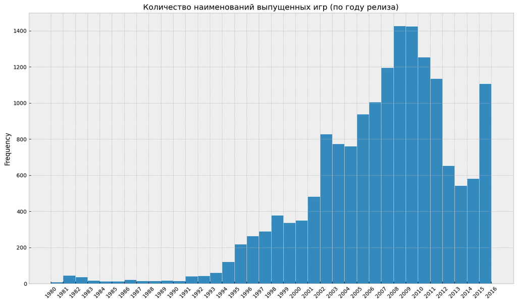

```python
bins = data['year_of_release'].max() - data['year_of_release'].min()
data['year_of_release'].plot(kind='hist',
                             bins=bins,
                             figsize=(16, 9),
                             title='Количество наименований выпущенных игр (по году релиза)',
                             xticks=np.arange(data['year_of_release'].min(), data['year_of_release'].max() + 1),
                             rot=45,
                             edgecolor='white');
```

По гистограмме видно, что до 1994-го года выпускалось стабильно малое количество игр. Убедимся в этом, посмотрев на численные значения.

```python
data.query('year_of_release <= 1995')['year_of_release'].value_counts()
```

```
1995    219
1994    121
1993     60
1981     46
1992     43
1991     41
1982     36
1986     21
1983     17
1989     17
1987     16
1990     16
1988     15
1984     14
1985     14
1980      9
Name: year_of_release, dtype: int64
```

Так и есть. Можно было бы не учитывать данные до 1994-го года, но, возможно, та небольшая номенклатура, что была выпущена издавалась миллиардами копий...

### Продажи игр для популярных платформ

к навигации

Посчитаем суммарное количество проданных копий по платформам.

```python
sales_by_platform = data.groupby('platform', as_index=False) \
                        .agg({'sales': 'sum'}) \
                        .sort_values(by='sales', ascending=False)
sales_by_platform
```

|  | platform | sales |
| --- | --- | --- |
| 16 | PS2 | 1233.56 |
| 28 | X360 | 961.24 |
| 17 | PS3 | 931.34 |
| 26 | Wii | 891.18 |
| 4 | DS | 802.78 |
| 15 | PS | 727.58 |
| 18 | PS4 | 314.14 |
| 6 | GBA | 312.88 |
| 19 | PSP | 289.53 |
| 2 | 3DS | 257.81 |
| 13 | PC | 255.76 |
| 5 | GB | 254.43 |
| 29 | XB | 251.57 |
| 11 | NES | 251.05 |
| 10 | N64 | 218.01 |
| 23 | SNES | 200.04 |
| 7 | GC | 196.73 |
| 30 | XOne | 159.32 |
| 0 | 2600 | 86.48 |
| 27 | WiiU | 82.19 |
| 20 | PSV | 53.81 |
| 21 | SAT | 33.59 |
| 8 | GEN | 28.35 |
| 3 | DC | 15.95 |
| 22 | SCD | 1.86 |
| 12 | NG | 1.44 |
| 25 | WS | 1.42 |
| 24 | TG16 | 0.16 |
| 1 | 3DO | 0.10 |
| 9 | GG | 0.04 |
| 14 | PCFX | 0.03 |

Можно выделить топ-6 платформ, проведя границу в районе 500 миллионов проданных копий.

```python
top_sales_platforms = sales_by_platform.head(6)['platform'].to_list()
top_sales_platforms
```

```
['PS2', 'X360', 'PS3', 'Wii', 'DS', 'PS']
```

Построим сводную таблицу: продажи по годам среди топ-6.

```python
top_6_data = data.query('platform in @top_sales_platforms')
top_6_sales = top_6_data.pivot_table(index='year_of_release',
                                     columns='platform',
                                     values='sales',
                                     aggfunc='sum')
top_6_sales
```

| platform year_of_release | DS | PS | PS2 | PS3 | Wii | X360 |
| --- | --- | --- | --- | --- | --- | --- |
| 1985 | 0.02 | NaN | NaN | NaN | NaN | NaN |
| 1994 | NaN | 6.03 | NaN | NaN | NaN | NaN |
| 1995 | NaN | 35.96 | NaN | NaN | NaN | NaN |
| 1996 | NaN | 94.70 | NaN | NaN | NaN | NaN |
| 1997 | NaN | 136.17 | NaN | NaN | NaN | NaN |
| 1998 | NaN | 169.49 | NaN | NaN | NaN | NaN |
| 1999 | NaN | 144.53 | NaN | NaN | NaN | NaN |
| 2000 | NaN | 96.37 | 39.17 | NaN | NaN | NaN |
| 2001 | NaN | 35.59 | 166.43 | NaN | NaN | NaN |
| 2002 | NaN | 6.67 | 205.38 | NaN | NaN | NaN |
| 2003 | NaN | 2.07 | 184.31 | NaN | NaN | NaN |
| 2004 | 17.27 | NaN | 211.81 | NaN | NaN | NaN |
| 2005 | 130.14 | NaN | 160.66 | NaN | NaN | 8.25 |
| 2006 | 119.81 | NaN | 103.42 | 20.96 | 137.15 | 51.62 |
| 2007 | 146.94 | NaN | 75.99 | 73.19 | 152.77 | 95.41 |
| 2008 | 145.31 | NaN | 53.90 | 118.52 | 171.32 | 135.26 |
| 2009 | 119.54 | NaN | 26.40 | 130.93 | 206.97 | 120.29 |
| 2010 | 85.02 | NaN | 5.64 | 142.17 | 127.95 | 170.03 |
| 2011 | 26.18 | NaN | 0.45 | 156.78 | 59.65 | 143.84 |
| 2012 | 11.01 | NaN | NaN | 107.36 | 21.71 | 99.74 |
| 2013 | 1.54 | NaN | NaN | 113.25 | 8.59 | 88.58 |
| 2014 | NaN | NaN | NaN | 47.76 | 3.75 | 34.74 |
| 2015 | NaN | NaN | NaN | 16.82 | 1.14 | 11.96 |
| 2016 | NaN | NaN | NaN | 3.60 | 0.18 | 1.52 |

В таблице есть явный артефакт: DS, 1985.

```python
data.query('platform == "DS" and year_of_release == 1985')
```

|  | name | platform | year_of_release | genre | na_sales | eu_sales | jp_sales | other_sales | critic_score | user_score | rating | sales |
| --- | --- | --- | --- | --- | --- | --- | --- | --- | --- | --- | --- | --- |
| 15957 | Strongest Tokyo University Shogi DS | DS | 1985 | Action | 0.0 | 0.0 | 0.02 | 0.0 | NaN | NaN | NaN | 0.02 |

Природа артефакта не ясна, но он тут явно лишний. Удалим.

```python
data = data.query('name != "Strongest Tokyo University Shogi DS"')
top_6_data = top_6_data.query('name != "Strongest Tokyo University Shogi DS"')
top_6_sales = top_6_sales.query('year_of_release != 1985')
```

Построим график.

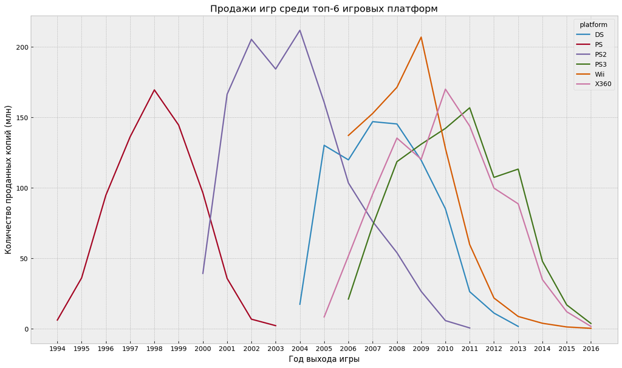

```python
top_6_sales.plot(figsize=(16, 9),
                 grid=True,
                 title='Продажи игр среди топ-6 игровых платформ',
                 xlabel='Год выхода игры',
                 ylabel='Количество проданных копий (млн)',
                 xticks=np.arange(1994, 2016 + 1));
```

Среди нашего топ-6 только 3 платформы дожили до 2016-го года и все они находятся в низшей точки падения продаж. По графику кажется, что срок жизни платформы - около 10 лет. Через 4-5 лет после старта продажи достигают пика, после чего наблюдается падение.  
Объявим функцию, иллюстрирующую жизненный цикл платформы.

```python
def get_life_circle(data):

    platform_circle = data.groupby('platform', as_index=False) \
                          .agg({'year_of_release': 'min'}) \
                          .merge(data.groupby('platform', as_index=False) \
                                     .agg({'year_of_release': 'max'}), on='platform') \
                          .merge(data.groupby(['platform', 'year_of_release'], as_index=False) \
                                     .agg({'sales': 'sum'}) \
                                     # получили таблицу платформа+год -> сумма продаж
                                     .groupby(['platform'], as_index=False) \
                                     .agg({'sales': 'max'}) \
                                     # получили таблицу платформа -> максимальное значение продаж
                                     .merge(data.groupby(['platform', 'year_of_release'], as_index=False) \
                                                .agg({'sales': 'sum'}),
                                            on=['sales', 'platform'], how='left'),
                                     on='platform') \
                          .rename(columns={'year_of_release_x': 'was_born',
                                             'year_of_release_y': 'died',
                                             'year_of_release': 'peak'}) \
                          .drop('sales', axis=1)

    platform_circle['lifetime'] = platform_circle['died'] - platform_circle['was_born']
    platform_circle['to_peak'] = platform_circle['peak'] - platform_circle['was_born']
    platform_circle['to_death'] = platform_circle['died'] - platform_circle['peak']

    platform_circle_values = platform_circle[['lifetime', 'to_peak', 'to_death']].describe().round(1)
    platform_circle = platform_circle.append(platform_circle_values)

    return platform_circle
```

Посмотрим на данные по топ-6 продаваемым платформам.

```python
get_life_circle(top_6_data)
```

|  | platform | was_born | died | peak | lifetime | to_peak | to_death |
| --- | --- | --- | --- | --- | --- | --- | --- |
| 0 | DS | 2004.0 | 2013.0 | 2007.0 | 9.0 | 3.0 | 6.0 |
| 1 | PS | 1994.0 | 2003.0 | 1998.0 | 9.0 | 4.0 | 5.0 |
| 2 | PS2 | 2000.0 | 2011.0 | 2004.0 | 11.0 | 4.0 | 7.0 |
| 3 | PS3 | 2006.0 | 2016.0 | 2011.0 | 10.0 | 5.0 | 5.0 |
| 4 | Wii | 2006.0 | 2016.0 | 2009.0 | 10.0 | 3.0 | 7.0 |
| 5 | X360 | 2005.0 | 2016.0 | 2010.0 | 11.0 | 5.0 | 6.0 |
| count | NaN | NaN | NaN | NaN | 6.0 | 6.0 | 6.0 |
| mean | NaN | NaN | NaN | NaN | 10.0 | 4.0 | 6.0 |
| std | NaN | NaN | NaN | NaN | 0.9 | 0.9 | 0.9 |
| min | NaN | NaN | NaN | NaN | 9.0 | 3.0 | 5.0 |
| 25% | NaN | NaN | NaN | NaN | 9.2 | 3.2 | 5.2 |
| 50% | NaN | NaN | NaN | NaN | 10.0 | 4.0 | 6.0 |
| 75% | NaN | NaN | NaN | NaN | 10.8 | 4.8 | 6.8 |
| max | NaN | NaN | NaN | NaN | 11.0 | 5.0 | 7.0 |

Средний срок жизни платформы - 10 лет. От рождения до пика проходит 4 года, после которого игры продаются еще 6 лет.  
Мы получили данные по самым продаваемым платформам, но для того, чтобы очертить круг актуальных данных, нужно взглянуть на всю выборку.

### Формирование датафрейма с актуальными данными

к навигации

Посмотрим на жизненный цикл всех платформ за все время.

```python
get_life_circle(data)
```

|  | platform | was_born | died | peak | lifetime | to_peak | to_death |
| --- | --- | --- | --- | --- | --- | --- | --- |
| 0 | 2600 | 1980.0 | 1989.0 | 1981.0 | 9.0 | 1.0 | 8.0 |
| 1 | 3DO | 1994.0 | 1995.0 | 1995.0 | 1.0 | 1.0 | 0.0 |
| 2 | 3DS | 2011.0 | 2016.0 | 2011.0 | 5.0 | 0.0 | 5.0 |
| 3 | DC | 1998.0 | 2008.0 | 2000.0 | 10.0 | 2.0 | 8.0 |
| 4 | DS | 2004.0 | 2013.0 | 2007.0 | 9.0 | 3.0 | 6.0 |
| 5 | GB | 1988.0 | 2001.0 | 1989.0 | 13.0 | 1.0 | 12.0 |
| 6 | GBA | 2000.0 | 2007.0 | 2004.0 | 7.0 | 4.0 | 3.0 |
| 7 | GC | 2001.0 | 2007.0 | 2002.0 | 6.0 | 1.0 | 5.0 |
| 8 | GEN | 1990.0 | 1994.0 | 1992.0 | 4.0 | 2.0 | 2.0 |
| 9 | GG | 1992.0 | 1992.0 | 1992.0 | 0.0 | 0.0 | 0.0 |
| 10 | N64 | 1996.0 | 2002.0 | 1999.0 | 6.0 | 3.0 | 3.0 |
| 11 | NES | 1983.0 | 1994.0 | 1985.0 | 11.0 | 2.0 | 9.0 |
| 12 | NG | 1993.0 | 1996.0 | 1994.0 | 3.0 | 1.0 | 2.0 |
| 13 | PC | 1985.0 | 2016.0 | 2011.0 | 31.0 | 26.0 | 5.0 |
| 14 | PCFX | 1996.0 | 1996.0 | 1996.0 | 0.0 | 0.0 | 0.0 |
| 15 | PS | 1994.0 | 2003.0 | 1998.0 | 9.0 | 4.0 | 5.0 |
| 16 | PS2 | 2000.0 | 2011.0 | 2004.0 | 11.0 | 4.0 | 7.0 |
| 17 | PS3 | 2006.0 | 2016.0 | 2011.0 | 10.0 | 5.0 | 5.0 |
| 18 | PS4 | 2013.0 | 2016.0 | 2015.0 | 3.0 | 2.0 | 1.0 |
| 19 | PSP | 2004.0 | 2015.0 | 2006.0 | 11.0 | 2.0 | 9.0 |
| 20 | PSV | 2011.0 | 2016.0 | 2012.0 | 5.0 | 1.0 | 4.0 |
| 21 | SAT | 1994.0 | 1999.0 | 1995.0 | 5.0 | 1.0 | 4.0 |
| 22 | SCD | 1993.0 | 1994.0 | 1993.0 | 1.0 | 0.0 | 1.0 |
| 23 | SNES | 1990.0 | 1999.0 | 1993.0 | 9.0 | 3.0 | 6.0 |
| 24 | TG16 | 1995.0 | 1995.0 | 1995.0 | 0.0 | 0.0 | 0.0 |
| 25 | WS | 1999.0 | 2001.0 | 2000.0 | 2.0 | 1.0 | 1.0 |
| 26 | Wii | 2006.0 | 2016.0 | 2009.0 | 10.0 | 3.0 | 7.0 |
| 27 | WiiU | 2012.0 | 2016.0 | 2014.0 | 4.0 | 2.0 | 2.0 |
| 28 | X360 | 2005.0 | 2016.0 | 2010.0 | 11.0 | 5.0 | 6.0 |
| 29 | XB | 2000.0 | 2008.0 | 2004.0 | 8.0 | 4.0 | 4.0 |
| 30 | XOne | 2013.0 | 2016.0 | 2015.0 | 3.0 | 2.0 | 1.0 |
| count | NaN | NaN | NaN | NaN | 31.0 | 31.0 | 31.0 |
| mean | NaN | NaN | NaN | NaN | 7.0 | 2.8 | 4.2 |
| std | NaN | NaN | NaN | NaN | 5.9 | 4.6 | 3.1 |
| min | NaN | NaN | NaN | NaN | 0.0 | 0.0 | 0.0 |
| 25% | NaN | NaN | NaN | NaN | 3.0 | 1.0 | 1.5 |
| 50% | NaN | NaN | NaN | NaN | 6.0 | 2.0 | 4.0 |
| 75% | NaN | NaN | NaN | NaN | 10.0 | 3.0 | 6.0 |
| max | NaN | NaN | NaN | NaN | 31.0 | 26.0 | 12.0 |

Из данных выбиваются явно провальные проекты, просуществовавшие год и менее, а также вечные персональные компьютеры. Исключим их из анализа.

```python
normal_platforms = get_life_circle(data).query('30 > lifetime > 1')['platform'].dropna().to_list()
get_life_circle(data.query('platform in @normal_platforms'))
```

|  | platform | was_born | died | peak | lifetime | to_peak | to_death |
| --- | --- | --- | --- | --- | --- | --- | --- |
| 0 | 2600 | 1980.0 | 1989.0 | 1981.0 | 9.0 | 1.0 | 8.0 |
| 1 | 3DS | 2011.0 | 2016.0 | 2011.0 | 5.0 | 0.0 | 5.0 |
| 2 | DC | 1998.0 | 2008.0 | 2000.0 | 10.0 | 2.0 | 8.0 |
| 3 | DS | 2004.0 | 2013.0 | 2007.0 | 9.0 | 3.0 | 6.0 |
| 4 | GB | 1988.0 | 2001.0 | 1989.0 | 13.0 | 1.0 | 12.0 |
| 5 | GBA | 2000.0 | 2007.0 | 2004.0 | 7.0 | 4.0 | 3.0 |
| 6 | GC | 2001.0 | 2007.0 | 2002.0 | 6.0 | 1.0 | 5.0 |
| 7 | GEN | 1990.0 | 1994.0 | 1992.0 | 4.0 | 2.0 | 2.0 |
| 8 | N64 | 1996.0 | 2002.0 | 1999.0 | 6.0 | 3.0 | 3.0 |
| 9 | NES | 1983.0 | 1994.0 | 1985.0 | 11.0 | 2.0 | 9.0 |
| 10 | NG | 1993.0 | 1996.0 | 1994.0 | 3.0 | 1.0 | 2.0 |
| 11 | PS | 1994.0 | 2003.0 | 1998.0 | 9.0 | 4.0 | 5.0 |
| 12 | PS2 | 2000.0 | 2011.0 | 2004.0 | 11.0 | 4.0 | 7.0 |
| 13 | PS3 | 2006.0 | 2016.0 | 2011.0 | 10.0 | 5.0 | 5.0 |
| 14 | PS4 | 2013.0 | 2016.0 | 2015.0 | 3.0 | 2.0 | 1.0 |
| 15 | PSP | 2004.0 | 2015.0 | 2006.0 | 11.0 | 2.0 | 9.0 |
| 16 | PSV | 2011.0 | 2016.0 | 2012.0 | 5.0 | 1.0 | 4.0 |
| 17 | SAT | 1994.0 | 1999.0 | 1995.0 | 5.0 | 1.0 | 4.0 |
| 18 | SNES | 1990.0 | 1999.0 | 1993.0 | 9.0 | 3.0 | 6.0 |
| 19 | WS | 1999.0 | 2001.0 | 2000.0 | 2.0 | 1.0 | 1.0 |
| 20 | Wii | 2006.0 | 2016.0 | 2009.0 | 10.0 | 3.0 | 7.0 |
| 21 | WiiU | 2012.0 | 2016.0 | 2014.0 | 4.0 | 2.0 | 2.0 |
| 22 | X360 | 2005.0 | 2016.0 | 2010.0 | 11.0 | 5.0 | 6.0 |
| 23 | XB | 2000.0 | 2008.0 | 2004.0 | 8.0 | 4.0 | 4.0 |
| 24 | XOne | 2013.0 | 2016.0 | 2015.0 | 3.0 | 2.0 | 1.0 |
| count | NaN | NaN | NaN | NaN | 25.0 | 25.0 | 25.0 |
| mean | NaN | NaN | NaN | NaN | 7.4 | 2.4 | 5.0 |
| std | NaN | NaN | NaN | NaN | 3.2 | 1.4 | 2.9 |
| min | NaN | NaN | NaN | NaN | 2.0 | 0.0 | 1.0 |
| 25% | NaN | NaN | NaN | NaN | 5.0 | 1.0 | 3.0 |
| 50% | NaN | NaN | NaN | NaN | 8.0 | 2.0 | 5.0 |
| 75% | NaN | NaN | NaN | NaN | 10.0 | 3.0 | 7.0 |
| max | NaN | NaN | NaN | NaN | 13.0 | 5.0 | 12.0 |

Средний срок жизни платформы по всей выборке - 7-8 лет, 2-3 года до пика продаж и 5 лет от высшей точки до прекращения продаж.  
Отсеем платфоры, данные о которых будут нерелевантны для построения прогноза, а именно:

1. прошедшие пик более 5-ти лет назад;
2. старше 7-ми лет.

```python
relevant_platforms = get_life_circle(data).query('peak >= 2011 and was_born >= 2009')['platform'].dropna().to_list()
if not 'PC' in relevant_platforms:
    relevant_platforms = relevant_platforms + ['PC']
relevant_platforms
```

```
['3DS', 'PS4', 'PSV', 'WiiU', 'XOne', 'PC']
```

```python
relevant_data = data.query('platform in @relevant_platforms and year_of_release > 2011')
relevant_data.info()
```

```
<class 'pandas.core.frame.DataFrame'>
Int64Index: 1843 entries, 31 to 16714
Data columns (total 12 columns):
 #   Column           Non-Null Count  Dtype
---  ------           --------------  -----
 0   name             1843 non-null   object
 1   platform         1843 non-null   object
 2   year_of_release  1843 non-null   int32
 3   genre            1843 non-null   object
 4   na_sales         1843 non-null   float64
 5   eu_sales         1843 non-null   float64
 6   jp_sales         1843 non-null   float64
 7   other_sales      1843 non-null   float64
 8   critic_score     920 non-null    float64
 9   user_score       1014 non-null   float64
 10  rating           1011 non-null   float64
 11  sales            1843 non-null   float64
dtypes: float64(8), int32(1), object(3)
memory usage: 180.0+ KB
```

Данные заметно похудели, но, вероятно, их достаточно для аналитики. Посмотрим на продажи живых платформ за актуальный период.

### Продажи игр для актуальных платформ за актуальный период

к навигации

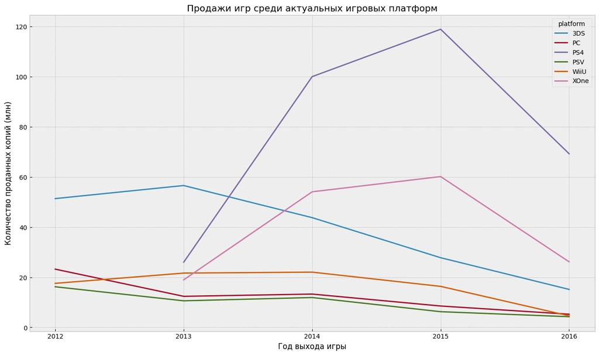

```python
relevant_data.pivot_table(index='year_of_release',
                          columns='platform',
                          values='sales',
                          aggfunc='sum') \
             .plot(figsize=(16, 9),
                   grid=True,
                   title='Продажи игр среди актуальных игровых платформ',
                   xlabel='Год выхода игры',
                   ylabel='Количество проданных копий (млн)',
                   xticks=np.arange(relevant_data['year_of_release'].min(), relevant_data['year_of_release'].max() + 1));
```

Снижение показателей в абсолютных значениях с 2015-го года может свидетельствовать как о падении рынка в целом, так и в недостаточном количестве данных за последний год. Посмотрим на позиции игроков относительно рынка.

```python
relevant_sales = relevant_data.pivot_table(index='year_of_release',
                               columns='platform',
                               values='sales',
                               aggfunc='sum')
relevant_sales['sum'] = relevant_sales.sum(axis=1)
relevant_sales
```

| platform year_of_release | 3DS | PC | PS4 | PSV | WiiU | XOne | sum |
| --- | --- | --- | --- | --- | --- | --- | --- |
| 2012 | 51.36 | 23.22 | NaN | 16.19 | 17.56 | NaN | 108.33 |
| 2013 | 56.57 | 12.38 | 25.99 | 10.59 | 21.65 | 18.96 | 146.14 |
| 2014 | 43.76 | 13.28 | 100.00 | 11.90 | 22.03 | 54.07 | 245.04 |
| 2015 | 27.78 | 8.52 | 118.90 | 6.25 | 16.35 | 60.14 | 237.94 |
| 2016 | 15.14 | 5.25 | 69.25 | 4.25 | 4.60 | 26.15 | 124.64 |

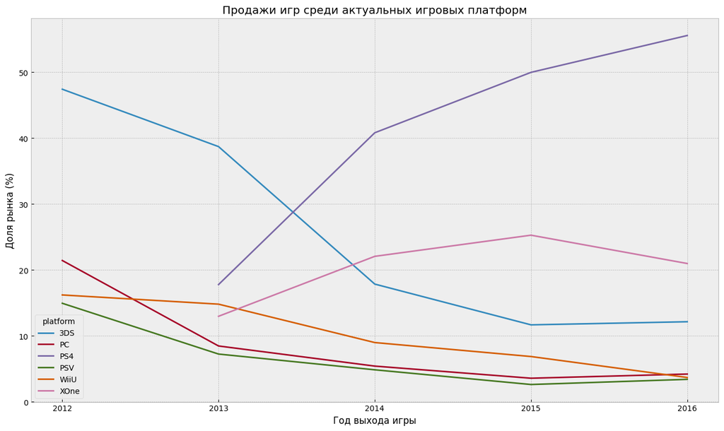

```python
for index in relevant_sales.index:
    relevant_sales.loc[index] = relevant_sales.loc[index] / relevant_sales.loc[index, 'sum'] * 100
relevant_sales = relevant_sales.drop(columns='sum')

relevant_sales.plot(figsize=(16, 9),
                    grid=True,
                    title='Продажи игр среди актуальных игровых платформ',
                    xlabel='Год выхода игры',
                    ylabel='Доля рынка (%)',
                    xticks=np.arange(relevant_data['year_of_release'].min(), relevant_data['year_of_release'].max() + 1));
```

Построим ящик с усами для продаж по платформам. Установим верхний порог значений по оси y равный Q3 + 1.5 * (Q3 - Q1) для платформы с наибольшими продажами (PS4), округленный до целого.

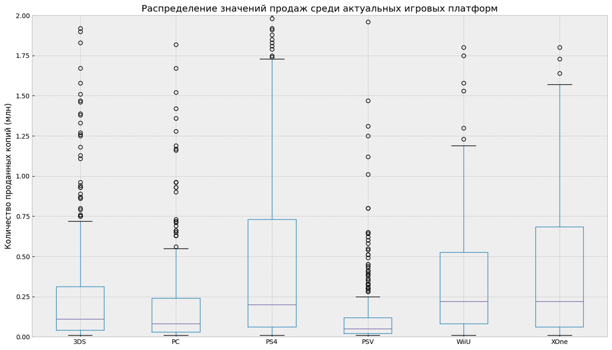

```python
box_data = relevant_data.pivot_table(index='name',
                                     columns='platform',
                                     values='sales',
                                     aggfunc='sum')

q1_q3 = np.percentile(box_data['PS4'].dropna(), [25, 75])
limit = round(q1_q3[1] + 1.5 * (q1_q3[1] - q1_q3[0]))

box_data.plot(kind='box',
             figsize=(16, 9),
             grid=True,
             title='Распределение значений продаж среди актуальных игровых платформ',
             ylabel='Количество проданных копий (млн)',
             ylim=(0, limit));
```

Не смотря на колоссальную разницу в суммарных продажах, медианные значения количества проданных копий для всех платформ не превышают 250 тысяч. Интересно также, что для Wiiu и XOne эти значения выше, чем у PS4.

### Влияние оценок критиков и пользователей на показатели продаж

к навигации

Посмотрим на корреляцию между оценками игр и числом проданных копий на платформе PS4. Не будем учитывать данные за 2016-й год, т.к., игра могла выйти в середине/конце года: оценки уже есть, а продаж пока нет.

```python
ps4_data = relevant_data.query('platform == "PS4" and year_of_release < 2016')
ps4_scores_sales = ps4_data[['critic_score', 'user_score', 'sales']]
ps4_scores_sales.corr()
```

|  | critic_score | user_score | sales |
| --- | --- | --- | --- |
| critic_score | 1.000000 | 0.612451 | 0.431848 |
| user_score | 0.612451 | 1.000000 | 0.024231 |
| sales | 0.431848 | 0.024231 | 1.000000 |

Показатель продаж хорошо коррелирует с оценками критиков и - никак - с оценками игроков. Для наглядности, построим диаграммы рассеяния.

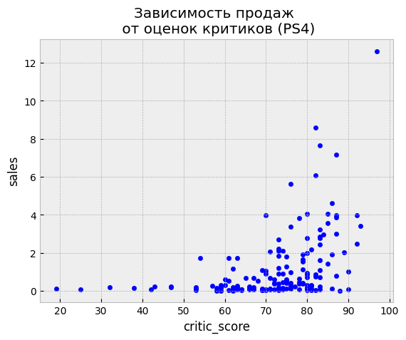

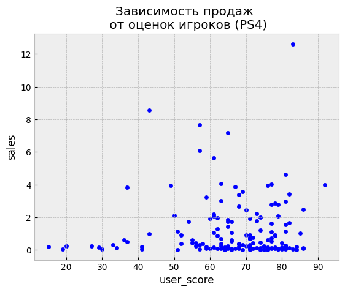

```python
ps4_scores_sales.plot(kind='scatter', x='critic_score', y='sales', title="Зависимость продаж \n от оценок критиков (PS4)");
ps4_scores_sales.plot(kind='scatter', x='user_score', y='sales', title="Зависимость продаж \n от оценок игроков (PS4)");
```

Сравним полученные закономерности с данными за весь период наблюдений...

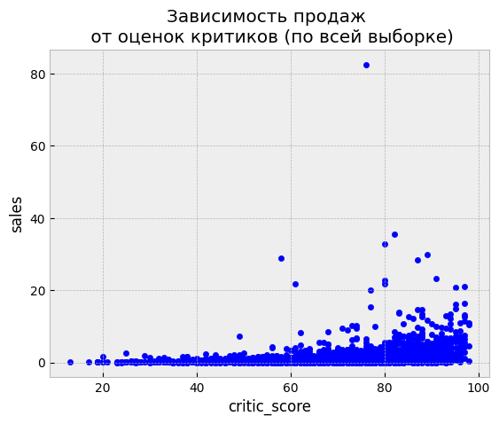

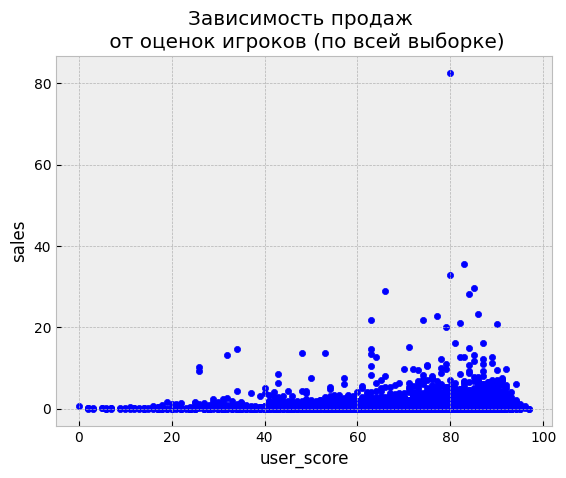

```python
data.plot(kind='scatter', x='critic_score', y='sales', title="Зависимость продаж \n от оценок критиков (по всей выборке)");
data.plot(kind='scatter', x='user_score', y='sales', title="Зависимость продаж \n от оценок игроков (по всей выборке)");
```

...и актуальный период.

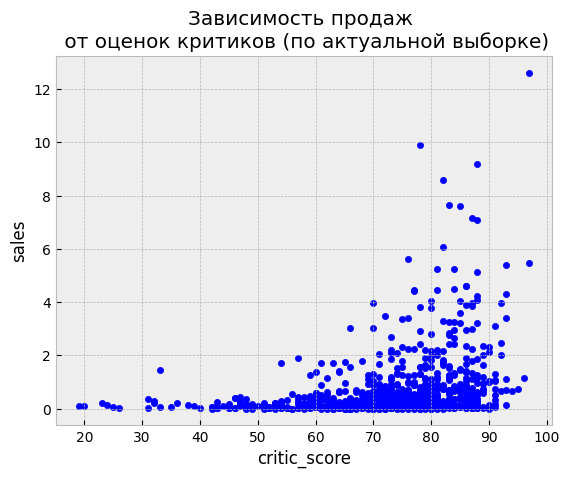

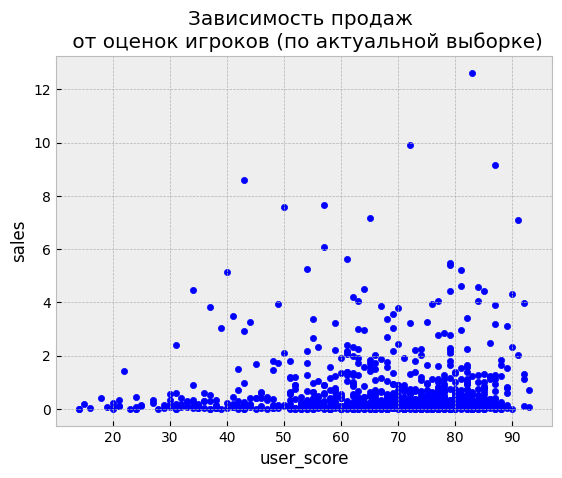

```python
relevant_data.plot(kind='scatter', x='critic_score', y='sales', title="Зависимость продаж \n от оценок критиков (по актуальной выборке)");
relevant_data.plot(kind='scatter', x='user_score', y='sales', title="Зависимость продаж \n от оценок игроков (по актуальной выборке)");
```

По графикам уже можно сделать выводы, но цифры - точнее!

```python
print('Корреляция между оценкой критиков и числом проданных копий')
print('По всей выборке:', round(data[['critic_score', 'sales']].corr().loc['critic_score', 'sales'], 2))
print('За актуальный период:', round(relevant_data[['critic_score', 'sales']].corr().loc['critic_score', 'sales'], 2))
print('Для PS4:', round(ps4_data[['critic_score', 'sales']].corr().loc['critic_score', 'sales'], 2))
print('Корреляция между оценкой игроков и числом проданных копий')
print('По всей выборке:', round(data[['user_score', 'sales']].corr().loc['user_score', 'sales'], 2))
print('За актуальный период:', round(relevant_data[['user_score', 'sales']].corr().loc['user_score', 'sales'], 2))
print('Для PS4:', round(ps4_data[['user_score', 'sales']].corr().loc['user_score', 'sales'], 2))
```

```
Корреляция между оценкой критиков и числом проданных копий
По всей выборке: 0.25
За актуальный период: 0.31
Для PS4: 0.43
Корреляция между оценкой игроков и числом проданных копий
По всей выборке: 0.09
За актуальный период: 0.03
Для PS4: 0.02
```

Корреляция между оценками критиков и продажами заметна на всех уровнях.  
Оценки игроков, как ни странно, вообще никак не влияют на продажи.

### Популярность жанров

к навигации

Посмотрим на данные в разрезе жанров. Пожалуй, как и в случае с платформами, интересней сравнивать доли рынка. Построим два графика:

1. по общей выборке;
2. за последние 4 года для актуальных платформ.

```python
def draw_plot(d):
    genre_sales = d.pivot_table(index='year_of_release',
                                columns='genre',
                                values='sales',
                                aggfunc='sum')
    genre_sales['sum'] = genre_sales.sum(axis=1)

    for index in genre_sales.index:
        genre_sales.loc[index] = genre_sales.loc[index] / genre_sales.loc[index, 'sum'] * 100
    genre_sales = genre_sales.drop(columns='sum')

    genre_sales.plot(figsize=(16, 9),
                     grid=True,
                     title='Доли рынка среди игр по жанрам',
                     xlabel='Год выхода игры',
                     ylabel='Доля рынка (%)',
                     xticks=np.arange(d['year_of_release'].min(), d['year_of_release'].max() + 1),
                     rot= 45 if d['year_of_release'].max() - d['year_of_release'].min() > 10 else 0)
```

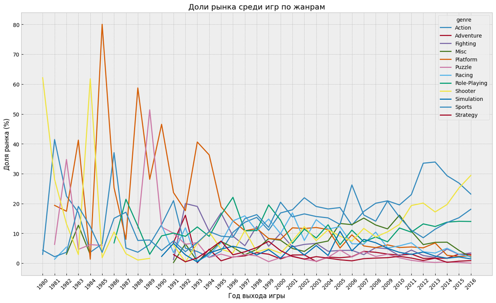

```python
draw_plot(data)
```

Интересным был, все-таки, период становления гейм-индустрии. В 84-м 62% рынка занимали шутеры, а платформеры - 2%. В 85-м - 2% у шутеров, 80% у платформеров. Более-менее устаканилось все в той же середине девяностых. Еще из интересного: есть годы, в которые не вышло ни одной игры определенного жанра. В 91-м, кажется, такое перестало происходить.

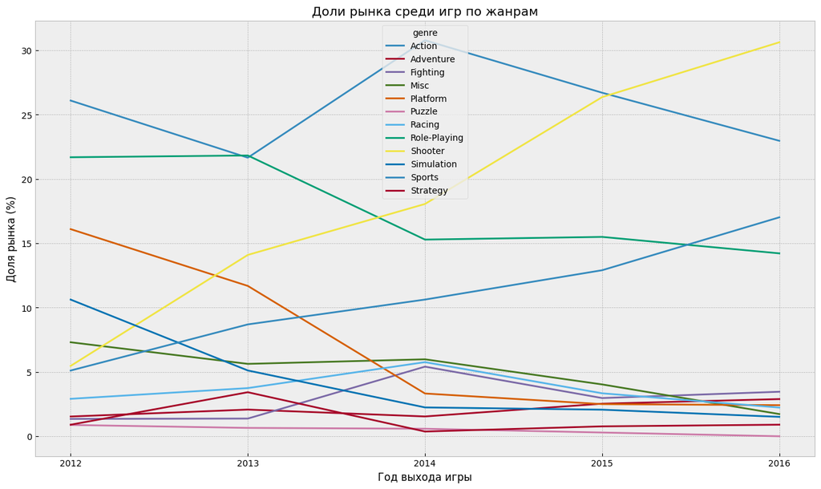

```python
draw_plot(relevant_data)
```

1. Все существовавшие когда-либо жанры дожили до наших дней!
2. К 2016-му году выделились 4 популярных жанра и - остальные, доля каждого из которых не превышает 4%.

### Продажи по регионам - популярные платформы, жанры и возрастные сегменты

к навигации

Объявим функцию создания сводной таблицы с данными о топ-5 популярных платформ и жанров по регионам.

```python
def get_region_sales(data, region):
    col = region + '_sales'

    sales_by_platform = data.groupby('platform', as_index=False) \
                            .agg({col: 'sum'}) \
                            .sort_values(by=col, ascending=False) \
                            .rename(columns={'platform': region + '_top_p', col: col + '_p'}) \
                            .reset_index(drop=True) \
                            .head(5)

    sales_by_genre = data.groupby('genre', as_index=False) \
                         .agg({col: 'sum'}) \
                         .sort_values(by=col, ascending=False) \
                         .rename(columns={'genre': region + '_top_g', col: col + '_g'}) \
                         .reset_index(drop=True) \
                         .head(5)

    region_sales = sales_by_platform.merge(sales_by_genre, left_index=True, right_index=True)

    return region_sales
```

Посмотрим на данные о продажах по регионам по общей выборке.

```python
print("""
na - Северная Америка
eu - Европа
jp - Япония
top_p - популярные платформы
sales_p - суммарные продажи игр для этих платформ (млн копий)
top_g - популярные жанры
sales_g - суммарные продажи игр в этих жаррах (млн копий)
""")

region_sales = get_region_sales(data, 'na').merge(get_region_sales(data, 'eu'),
                                                  left_index=True, right_index=True) \
                                           .merge(get_region_sales(data, 'jp'),
                                                  left_index=True, right_index=True)

region_sales
```

```
na - Северная Америка
eu - Европа
jp - Япония
top_p - популярные платформы
sales_p - суммарные продажи игр для этих платформ (млн копий)
top_g - популярные жанры
sales_g - суммарные продажи игр в этих жаррах (млн копий)
```

|  | na_top_p | na_sales_p | na_top_g | na_sales_g | eu_top_p | eu_sales_p | eu_top_g | eu_sales_g | jp_top_p | jp_sales_p | jp_top_g | jp_sales_g |
| --- | --- | --- | --- | --- | --- | --- | --- | --- | --- | --- | --- | --- |
| 0 | X360 | 595.74 | Action | 863.17 | PS2 | 332.63 | Action | 510.99 | DS | 175.00 | Role-Playing | 353.39 |
| 1 | PS2 | 572.92 | Sports | 671.20 | PS3 | 327.21 | Sports | 371.33 | PS | 139.78 | Action | 160.12 |
| 2 | Wii | 486.87 | Shooter | 584.83 | X360 | 268.32 | Shooter | 314.52 | PS2 | 137.54 | Sports | 134.93 |
| 3 | PS3 | 390.13 | Platform | 444.44 | Wii | 258.32 | Racing | 234.49 | SNES | 116.55 | Platform | 130.71 |
| 4 | DS | 380.31 | Misc | 399.57 | PS | 212.39 | Misc | 210.60 | 3DS | 100.62 | Misc | 107.02 |

В Америке и Европе топы платформ и жанров похожи. В Японии лидируют другие приставки (предположим, что - японские), а среди жанров, с большим отрывом - ролевые игры (в Америке и Европе они не вошли в топ). А вот в Японский топ не вошли популярные на западе шутеры.

Посмотрим на данные о продажах по регионам по актуальным платформам за актуальный период.

```python
region_sales = get_region_sales(relevant_data, 'na').merge(get_region_sales(relevant_data, 'eu'),
                                                           left_index=True, right_index=True) \
                                                    .merge(get_region_sales(relevant_data, 'jp'),
                                                           left_index=True, right_index=True)

region_sales
```

|  | na_top_p | na_sales_p | na_top_g | na_sales_g | eu_top_p | eu_sales_p | eu_top_g | eu_sales_g | jp_top_p | jp_sales_p | jp_top_g | jp_sales_g |
| --- | --- | --- | --- | --- | --- | --- | --- | --- | --- | --- | --- | --- |
| 0 | PS4 | 108.74 | Action | 85.40 | PS4 | 141.09 | Action | 83.00 | 3DS | 87.79 | Role-Playing | 51.06 |
| 1 | XOne | 93.12 | Shooter | 77.76 | XOne | 51.59 | Shooter | 67.62 | PSV | 21.04 | Action | 34.26 |
| 2 | 3DS | 55.31 | Role-Playing | 46.92 | 3DS | 42.64 | Sports | 41.10 | PS4 | 15.96 | Misc | 10.53 |
| 3 | WiiU | 38.10 | Sports | 38.71 | PC | 37.76 | Role-Playing | 38.48 | WiiU | 13.01 | Simulation | 9.61 |
| 4 | PC | 19.12 | Platform | 20.82 | WiiU | 25.13 | Platform | 17.81 | XOne | 0.34 | Platform | 8.55 |

В актуальной выборке номенклатуры по регионам отличаются уже не так сильно. Глобализация. Ролевые игры стали более популярны на западе. Из японского топа исчезли спортивные игры.

Визуализируем данные о продажах по регионам и возрастным рейтингам. Сравним показатели за весь период и актуальные данные.

```python
def draw_plot_2(data, period):

    data[['na_sales',
          'eu_sales',
          'jp_sales',
          'rating']].groupby('rating').sum() \
                    .plot(figsize=(11, 4),
                          kind='bar',
                          grid=True,
                          title=('Продажи игр по регионам \n в зависимости от возрастного рейтинга (за ' + period),
                          xlabel='Возрастной рейтинг',
                          ylabel='Количество проданных копий (млн)',
                          rot=0)
```

```
1 - игры для всех
2 - игры для детей от 10 лет
3 - игры для подростков
4 - игры для взрослых
```

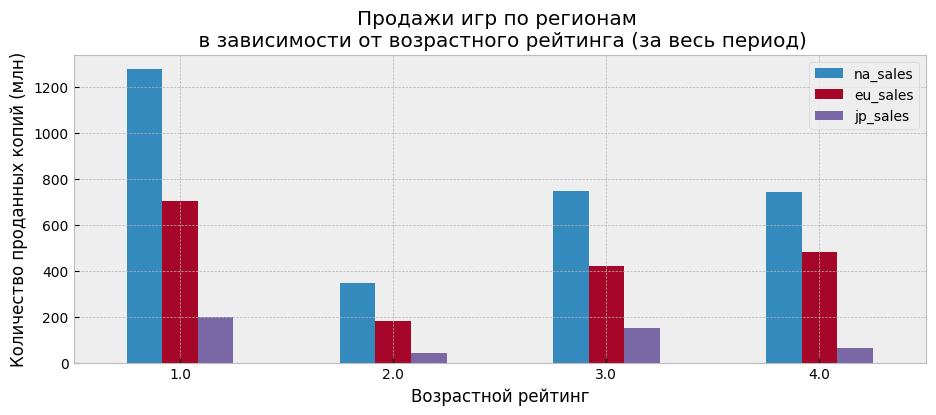

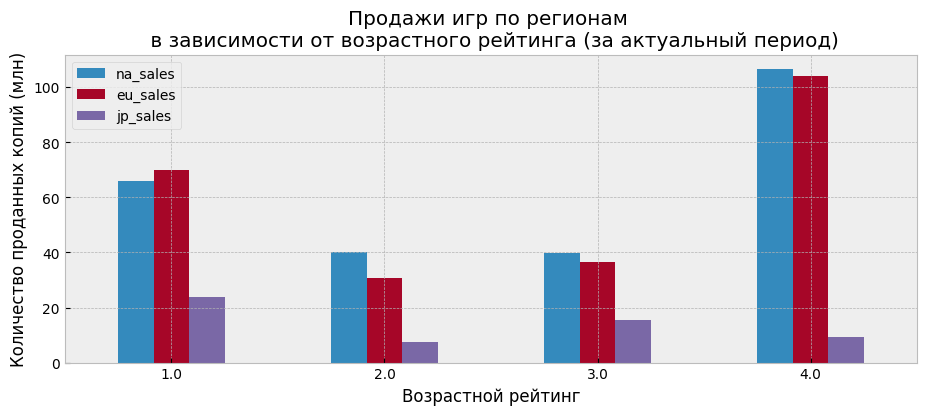

```python
print("""
1 - игры для всех
2 - игры для детей от 10 лет
3 - игры для подростков
4 - игры для взрослых
""")

data_list = [data, relevant_data]
period_list = ['весь период)', 'актуальный период)']
for i in range(2):
    draw_plot_2(data_list[i], period_list[i])
```

Среди общей выборки по всем регионам лидируют игры для всех возрастов. Примерно одинаковые показатели продаж подростковых и взрослых игр в Америке и Европе отличаются от долей в Японии - в ней игр для взрослых продалось в 2 раза меньше, чем для подростков.  
Актуальные данные демонстрируют иную картину. В Америке и Европе наиболее популярны игры для взрослых. В Японии, как и в первом случае - игры для всех возрастов, а на втором месте - подростковые.

## Проверка гипотез о пользовательских оценках

к навигации

Проверим две гипотезы о средних пользовательских рейтингах на актуальной выборке. Для начала, посмотрим, как распределены значения между 2.5 и 97.5 перцентилями.

```python
np.percentile(relevant_data['user_score'].dropna(), [2.5, 97.5])
```

```
array([30., 88.])
```

Менее 5% данных (в сумме) превышают значение 88 и меньше 30. Установим эти значения в качестве пороговых.

```python
b_value = np.percentile(relevant_data['user_score'].dropna(), [2.5, 97.5])
```

Объявим функцию для проведения Ти-теста.

```python
def t_test(data_1, data_2, equal_var):

    r = st.ttest_ind(data_1, data_2, equal_var=equal_var)
    alpha = 0.05
    text = """Статистика разности равна {0:.5f}.
Вероятность получить такой результат случайно: {1:.5f}%.""" \
             .format(abs(r[0]), r.pvalue * 100)
    print(text)
    if r.pvalue < alpha:
        print('Отвергаем нулевую гипотезу.')
    else:
        print('Не получилось отвергнуть нулевую гипотезу.')
```

### Первая гипотеза: Xbox One и PC

к навигации

Проверим первую гипотезу.  
H0: Средние пользовательские рейтинги платформ Xbox One и PC одинаковые. Тогда...  
H1: Средние пользовательские рейтинги платформ Xbox One и PC НЕ одинаковые.  
Сформируем генеральные совокупности и посмотрим на их размер.

```python
x_one_scores = relevant_data.query('platform == "XOne" and @b_value[0] < user_score < @b_value[1]')['user_score'] \
                            .dropna()
pc_scores = relevant_data.query('platform == "PC" and @b_value[0] < user_score < @b_value[1]')['user_score'] \
                         .dropna()

print('Размер совокупности x_one_scores:', len(x_one_scores))
print('Размер pc_scores:', len(pc_scores))
```

```
Размер совокупности x_one_scores: 179
Размер pc_scores: 196
```

Размер выборок не сильно отличается, поэтому, при проведении Ти-теста используем параметр equal_var=True.  
Проведем Ти-тест.

```python
t_test(x_one_scores, pc_scores, True)
```

```
Статистика разности равна 0.31507.
Вероятность получить такой результат случайно: 75.28810%.
Не получилось отвергнуть нулевую гипотезу.
```

Посмотрим на значения.

```python
print('Средний пользовательский рейтинг игр для Xbox One: {0:.1f}, а для PC: {1:.1f}.'
     .format(x_one_scores.mean(), pc_scores.mean()))
```

```
Средний пользовательский рейтинг игр для Xbox One: 65.6, а для PC: 66.0.
```

Значения действительно очень близки.

### Вторая гипотеза: Action и Sports

к навигации

Проверим вторую гипотезу.  
H0: Средние пользовательские рейтинги жанров Action и Sports одинаковые.  
H1: Средние пользовательские рейтинги жанров Action и Sports НЕ одинаковые.  
Сформируем генеральные совокупности и посмотрим на их размер.

```python
action_scores = relevant_data.query('genre == "Action" and @b_value[0] < user_score < @b_value[1]')['user_score'] \
                             .dropna()
sports_scores = relevant_data.query('genre == "Sports" and @b_value[0] < user_score < @b_value[1]')['user_score'] \
                             .dropna()

print('Размер совокупности action_scores:', len(action_scores))
print('Размер sports_scores:', len(sports_scores))
```

```
Размер совокупности action_scores: 333
Размер sports_scores: 103
```

Размеры совокупностей заметно различаются, используем параметр equal_var=False.

```python
t_test(action_scores, sports_scores, False)
```

```
Статистика разности равна 6.80189.
Вероятность получить такой результат случайно: 0.00000%.
Отвергаем нулевую гипотезу.
```

P-value ничтожен, оценки явно различаются.

```python
print('Средний пользовательский рейтинг игр жанра Action: {0:.1f}, Sports: {1:.1f}.'
     .format(action_scores.mean(), sports_scores.mean()))
```

```
Средний пользовательский рейтинг игр жанра Action: 69.2, Sports: 59.5.
```

Значения отличаются на 10 пунктов!

## Выводы и рекомендации

к навигации

В ходе исследования удалось выявить следующие особенности рынка видеоигр:

1. Предпочтения пользователей меняются от года к году. Это касается и жанров и возрастных сегментов.
2. Средний срок жизни игровой консоли - около 7-ми лет. Пик продаж наступает через 2-3 года.
3. Мы очертили круг данных, которые можно считать актуальными - платформы, начавшие выпускаться не более 7-ми лет назад, и прошедших пик продаж - не менее 5-ти.
4. В 2016-м году наибольшую долю рынка занимают игры для PS4 и Xbox One.
5. Оценки игроков никогда не влияли на продажи, в отличае от оценок критиков.
6. В 2016-м наиболее популярны шутеры, игры в жанре экшн, спортивные и ролевые.
7. На рынке видео-игр существует региональная специфика. Она касается не только платформ, но и жанров.